# Midwest Project

parimala

2023-11-27

# Midwest dataset project by Parimala Anjanappa

The Midwest dataset is a collection of socio-economic and demographic data of Midwest state counties of the United States. Motivated by the need to understand and address potential disparities that may exist among different racial groups within this region made me choose this dataset, which can give some insights into this topic.

In this project, I aim to conduct a comprehensive analysis of demographic and socioeconomic data for counties in the Midwest region of the United States. The dataset, provides information on various factors, including population, race percentages, educational attainment, and poverty rates- which can help in understanding the complex interplay between demographic variables in the Midwest.

Loading all required libraries:

```r
#loading libraries
library(tidyverse)
```

```r
library(dplyr)
library(ggplot2)
library(broom)
```

# About the dataset

The Midwest dataset is a collection of socio-economic and demographic data of Midwest state counties of the United States. Motivated by the need to understand and address potential disparities that may exist among different racial groups within this region made me choose this dataset, which can give some insights into this topic.

Dataset in the form of a data frame with 437 rows and 28 variables. Each row represents a county, and the variables provide various demographic and socio-economic information for each county.

```r
data("midwest")
df<-midwest
colnames(midwest)
```

```
##  [1] "PID"                  "county"               "state"
##  [4] "area"                 "poptotal"             "popdensity"
##  [7] "popwhite"             "popblack"             "popamerindian"
## [10] "popasian"             "popother"             "percwhite"
## [13] "percblack"            "percamerindan"        "percasian"
## [16] "percother"            "popadults"            "perchsd"
## [19] "percollege"           "percprof"             "poppovertyknown"
## [22] "percpovertyknown"     "percbelowpoverty"     "percchildbelowpovert"
## [25] "percadultpoverty"     "percelderlypoverty"   "inmetro"
## [28] "category"
```

Here’s a brief explanation of the key columns:

- PID: Unique identifier for each observation.
- county: Name of the county.
- state: State to which the county belongs.
- area: Area of the county.
- poptotal: Total population of the county.
- popdensity: Population density, calculated as the total population divided by the area.
- popwhite, popblack, popamerindian, popasian, popother: Population counts based on different racial groups.
- percwhite, percblack, percamerindan, percasian, percother: Percentage of the total population corresponding to different racial groups.
- popadults: Population count of adults.
- perchsd, percollege, percprof: Percentages of the population with a high school diploma, college degree, and professional degree, respectively.
- poppovertyknown: Population count for which poverty status is known.
- percpovertyknown: Percentage of the population for which poverty status is known.
- percbelowpoverty: Percentage of the population below the poverty line.
- percchildbelowpovert, percadultpoverty, percelderlypoverty: Percentages of children, adults, and elderly individuals below the poverty line.
- inmetro: Binary indicator (0 or 1) representing whether the county is in a metropolitan area.
- category: Categorical variable indicating the category of the county.

This dataset provides a comprehensive snapshot of demographic and socio-economic features, allowing for in-depth analyses and insights into the characteristics of Midwest counties.

# Basic EDA to understand the data

Here I am trying to explore whether higher population or higher population density is associated with higher or lower poverty rates, or if there are disparities in education levels based on population density.

### Population in midwest

The total population is a fundamental demographic indicator that provides an overview of the size of the resident population in each state.

Illinois has the highest total population among the listed states, followed by Ohio, Michigan, Indiana, and Wisconsin.

```r
total_population_by_state <- df %>%
  group_by(state) %>%
  summarise(total_population = sum(poptotal, na.rm = TRUE)) %>%
  arrange(desc(total_population))
print(total_population_by_state)
```

```
## # A tibble: 5 × 2
##   state total_population
##   <chr>            <int>
## 1 IL            11430602
## 2 OH            10847115
## 3 MI             9295297
## 4 IN             5544159
## 5 WI             4891769
```

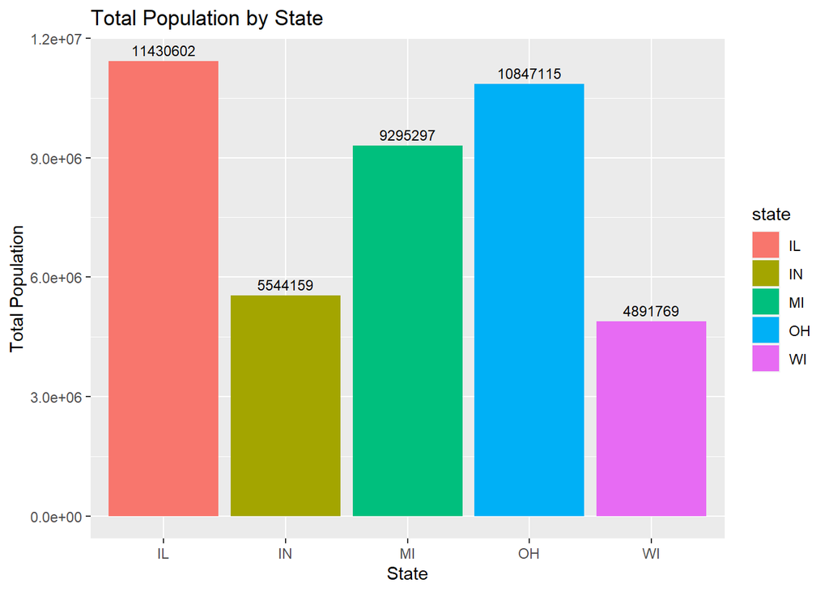

```r
ggplot(total_population_by_state, aes(x = state, y = total_population, fill = state)) +
  geom_bar(stat = "identity") +
  geom_text(aes(label = sprintf("%d", total_population)),
            position = position_dodge(width = 0.9), vjust = -0.5, color = "black", size = 3) +
  labs(title = "Total Population by State",
       x = "State",
       y = "Total Population")
```

### Population density in midwest

Population density is a measure of the number of people living per unit of area, typically per square mile or square kilometer. Ohio has the highest mean population density among the listed states, followed by Michigan, Illinois, Indiana, and Wisconsin. Ohio tends to have a higher concentration of people per unit of area compared to the other states in the dataset.

```r
popdensity_data <- df %>%
  group_by(state) %>%
  summarise(mean_popdensity = mean(popdensity, na.rm = TRUE)) %>%
  arrange(desc(mean_popdensity))
popdensity_data
```

```
## # A tibble: 5 × 2
##   state mean_popdensity
##   <chr>           <dbl>
## 1 OH              4639.
## 2 MI              3011.
## 3 IL              2824.
## 4 IN              2573.
## 5 WI              2373.
```

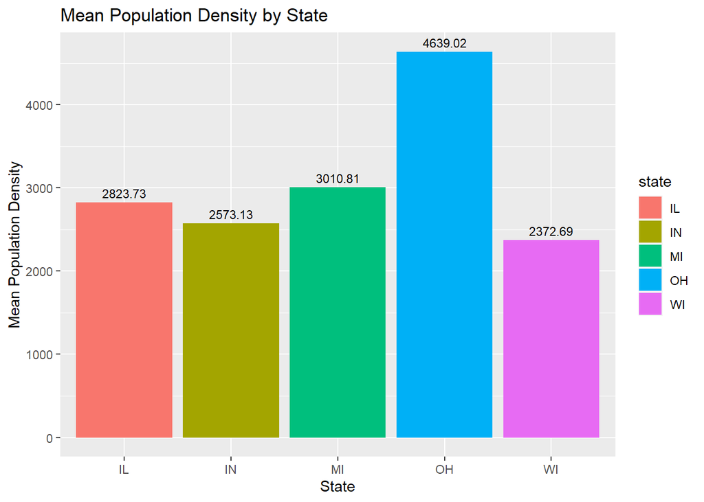

```r
# Bar plot for population density by state
ggplot(popdensity_data, aes(x = state, y = mean_popdensity, fill = state)) +
  geom_bar(stat = "identity") +
  geom_text(aes(label = sprintf("%.2f", mean_popdensity)),
            position = position_dodge(width = 0.9), vjust = -0.5, color = "black", size = 3) +
  labs(title = "Mean Population Density by State",
       x = "State",
       y = "Mean Population Density")
```

### Poverty in midwest

```
## No summary function supplied, defaulting to `mean_se()`
```

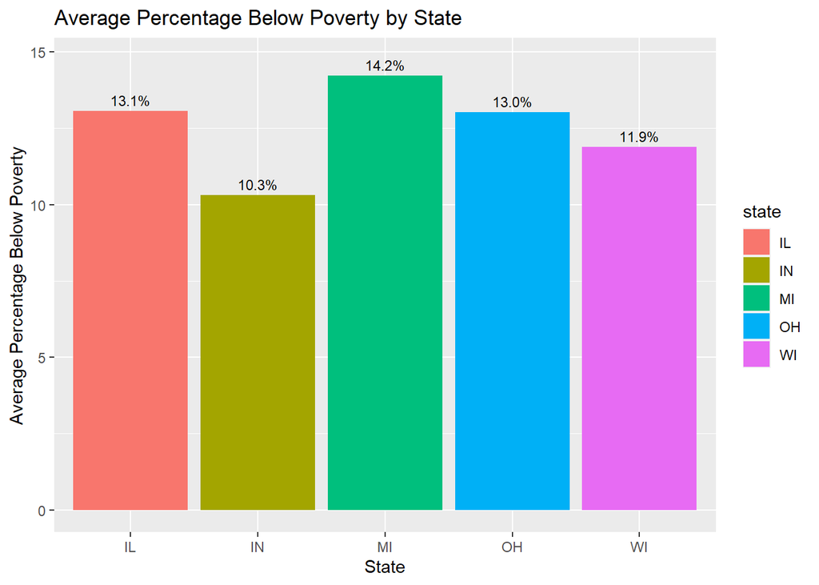

```r
ggplot(df, aes(x = state, y = percbelowpoverty, fill = state)) +
  geom_bar(stat = "summary", fun = "mean", position = position_dodge2(width = 0.5)) +
  geom_text(stat = "summary", aes(label = sprintf("%.1f%%", after_stat(y))),
            position = position_dodge2(width = 0.8), vjust = -0.5, color = "black", size = 3) +
  labs(title = "Average Percentage Below Poverty by State", x = "State", y = "Average Percentage Below Poverty")
```

### Poverty vs population and population density

Explore the relationship between the percentage below poverty (percbelowpoverty) and both the total population (poptotal) and population density (popdensity).

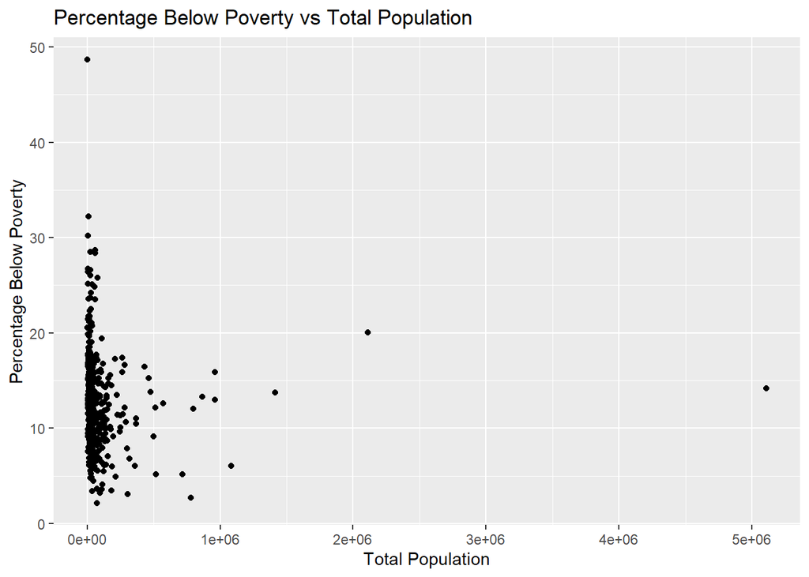

```r
# Scatter plot for percbelowpoverty vs poptotal
ggplot(df, aes(x = poptotal, y = percbelowpoverty)) +
  geom_point() +
  labs(title = "Percentage Below Poverty vs Total Population",
       x = "Total Population",
       y = "Percentage Below Poverty")
```

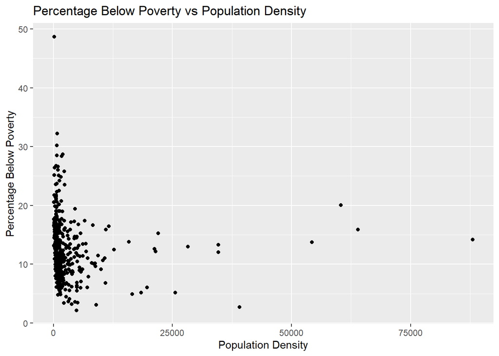

```r
# Scatter plot for percbelowpoverty vs popdensity
ggplot(df, aes(x = popdensity, y = percbelowpoverty)) +
  geom_point() +
  labs(title = "Percentage Below Poverty vs Population Density",
       x = "Population Density",
       y = "Percentage Below Poverty")
```

#### Correlation

```r
#correlation between poptotal and percbelowpoverty
correlation_poptotal <- cor(df$poptotal, df$percbelowpoverty)
correlation_poptotal
```

```
## [1] -0.02869561
```

Correlation coefficient here is close to zero, meaning that changes in the total population are not associated with a consistent or meaningful linear change in the percentage below poverty. The negative sign suggests a weak negative correlation, but the magnitude is so small that the relationship is practically negligible.

```r
#correlation between popdensity and percbelowpoverty
correlation_popdensity <- cor(df$popdensity, df$percbelowpoverty)
correlation_popdensity
```

```
## [1] -0.05211462
```

The correlation coefficient of approximately -0.0521 between popdensity and percbelowpoverty also indicates a very weak negative linear relationship. Similar to the correlation with poptotal, the value is close to zero, suggesting that there is little to no linear correlation between population density and the percentage below poverty.

#### Linear modeling

```r
lm_model_poptotal <- lm(percbelowpoverty ~ poptotal, data = df)
summary(lm_model_poptotal)
```

```
##
## Call:
## lm(formula = percbelowpoverty ~ poptotal, data = df)
##
## Residuals:
##     Min      1Q  Median      3Q     Max
## -10.342  -3.287  -0.719   2.610  36.135
##
## Coefficients:
##               Estimate Std. Error t value Pr(>|t|)
## (Intercept)  1.256e+01  2.591e-01  48.474   <2e-16 ***
## poptotal    -4.956e-07  8.278e-07  -0.599     0.55
## ---
## Signif. codes:  0 '***' 0.001 '**' 0.01 '*' 0.05 '.' 0.1 ' ' 1
##
## Residual standard error: 5.154 on 435 degrees of freedom
## Multiple R-squared:  0.0008234,  Adjusted R-squared:  -0.001474
## F-statistic: 0.3585 on 1 and 435 DF,  p-value: 0.5497
```

The p-value for poptotal is high, indicating that changes in total population are not associated with statistically significant changes in the percentage below poverty

```r
lm_model_popdensity <- lm(percbelowpoverty ~ popdensity, data = df)
summary(lm_model_popdensity)
```

```
##
## Call:
## lm(formula = percbelowpoverty ~ popdensity, data = df)
##
## Residuals:
##     Min      1Q  Median      3Q     Max
## -10.269  -3.321  -0.775   2.621  36.079
##
## Coefficients:
##               Estimate Std. Error t value Pr(>|t|)
## (Intercept)  1.262e+01  2.657e-01  47.491   <2e-16 ***
## popdensity  -3.502e-05  3.217e-05  -1.088    0.277
## ---
## Signif. codes:  0 '***' 0.001 '**' 0.01 '*' 0.05 '.' 0.1 ' ' 1
##
## Residual standard error: 5.149 on 435 degrees of freedom
## Multiple R-squared:  0.002716,   Adjusted R-squared:  0.0004233
## F-statistic: 1.185 on 1 and 435 DF,  p-value: 0.277
```

Given these findings, it does not appear that poptotal or popdensity are strong predictors of the percentage below the poverty line. On the other hand, we can see affect on race on poverty and education.

# Exploring the Relationship Between Race and Socioeconomic Features in the Midwest

## Basic EDA to understand the variations between different factors affecting Socioeconomic Features

```r
state_percblack <- df %>%
  group_by(state) %>%
  summarise(mean_percblack = mean(percblack, na.rm = TRUE)) %>%
  arrange(desc(mean_percblack)) %>%
  print()
```

```
## # A tibble: 5 × 2
##   state mean_percblack
##   <chr>          <dbl>
## 1 IL             3.65
## 2 OH             3.51
## 3 MI             3.07
## 4 IN             1.89
## 5 WI             0.822
```

```r
print(state_percblack)
```

```
## # A tibble: 5 × 2
##   state mean_percblack
##   <chr>          <dbl>
## 1 IL             3.65
## 2 OH             3.51
## 3 MI             3.07
## 4 IN             1.89
## 5 WI             0.822
```

- Illinois (IL) has the highest mean percentage of Black population among the listed states, followed by Ohio (OH), Michigan (MI), Indiana (IN), and Wisconsin (WI).
- Wisconsin (WI) has the lowest mean percentage of Black population among the listed states.
- The differences in mean percentages suggest variations in the racial composition across states. Further analysis, such as correlation with other variables or comparison with socioeconomic factors, can provide insights into potential relationships and disparities.

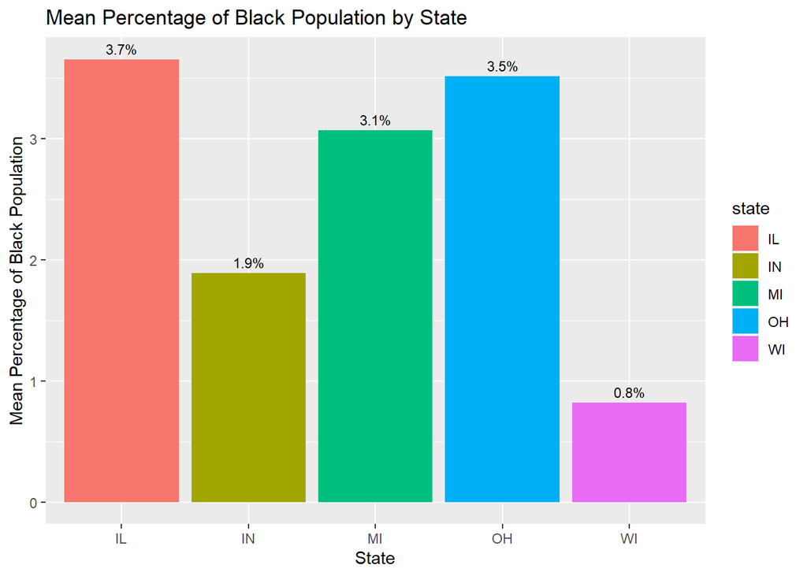

```r
# Bar plot
ggplot(state_percblack, aes(x = state, y = mean_percblack, fill = state)) +
  geom_bar(stat = "identity") +
  geom_text(aes(label = sprintf("%.1f%%", mean_percblack)),
            position = position_dodge(width = 0.9), vjust = -0.5, color = "black", size = 3) +
  labs(title = "Mean Percentage of Black Population by State",
       x = "State",
       y = "Mean Percentage of Black Population")
```

For ease of analysis I have grouped race other than popblack and popwhite to other_race: So, there’ll be popwhite poblack and otherrace to explore the socio economic features further

```r
#grouping races other than popwhite for future analysis
df3 <- df%>%
  mutate(other_race= percasian+percamerindan+percother)

other_race_percpop <- df3 %>%
  group_by(state) %>%
  summarise(mean_other = mean(other_race, na.rm = TRUE)) %>%
  arrange(desc(mean_other))
print(other_race_percpop)
```

```
## # A tibble: 5 × 2
##   state mean_other
##   <chr>      <dbl>
## 1 WI         3.39
## 2 MI         2.49
## 3 IL         1.39
## 4 OH         1.09
## 5 IN         0.903
```

- Wisconsin (WI) has the highest mean percentage of the “other” racial group among the listed states, followed by Michigan (MI), Illinois (IL), Ohio (OH), and Indiana (IN).
- Indiana (IN) has the lowest mean percentage of the “other” racial group among the listed states.

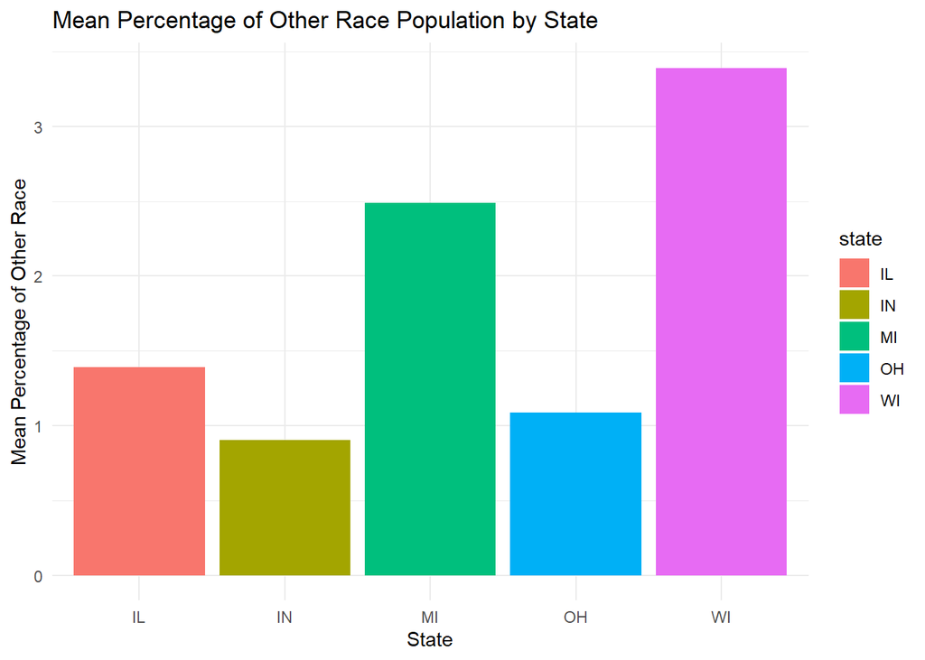

```r
ggplot(other_race_percpop, aes(x = state, y = mean_other, fill = state)) +
  geom_bar(stat = "identity") +
  labs(title = "Mean Percentage of Other Race Population by State",
       x = "State",
       y = "Mean Percentage of Other Race") +
  theme_minimal()
```

Adding percblack to other race:

```r
df4 <- df%>%
  mutate(others= percblack+percasian+percamerindan+percother)

excluding_popwhite <- df4 %>%
  group_by(state) %>%
  summarise(mean_others_1 = mean(others, na.rm = TRUE)) %>%
  arrange(desc(mean_others_1))
print(excluding_popwhite)
```

```
## # A tibble: 5 × 2
##   state mean_others_1
##   <chr>         <dbl>
## 1 MI             5.56
## 2 IL             5.04
## 3 OH             4.60
## 4 WI             4.21
## 5 IN             2.79
```

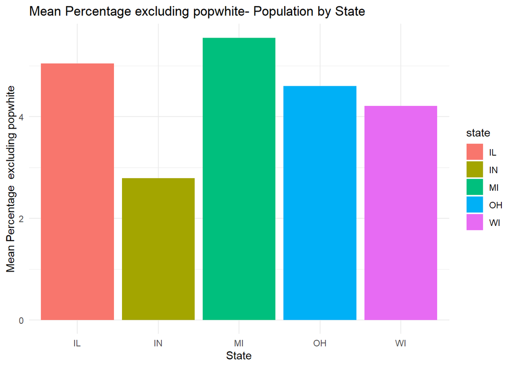

```r
ggplot(excluding_popwhite, aes(x = state, y = mean_others_1, fill = state)) +
  geom_bar(stat = "identity") +
  labs(title = "Mean Percentage excluding popwhite- Population by State",
       x = "State",
       y = "Mean Percentage  excluding popwhite") +
  theme_minimal()
```

```r
statewise_poverty <- df %>%
  group_by(state) %>%
  summarise(mean_percbelowpoverty = mean(percbelowpoverty, na.rm = TRUE)) %>%
  arrange(desc(mean_percbelowpoverty))
print(statewise_poverty)
```

```
## # A tibble: 5 × 2
##   state mean_percbelowpoverty
##   <chr>                 <dbl>
## 1 MI                     14.2
## 2 IL                     13.1
## 3 OH                     13.0
## 4 WI                     11.9
## 5 IN                     10.3
```

- Michigan (MI) has the highest mean percentage below the poverty line among the listed states, followed by Illinois (IL), Ohio (OH), Wisconsin (WI), and Indiana (IN).
- Indiana has the lowest mean percentage below the poverty line among the listed states.

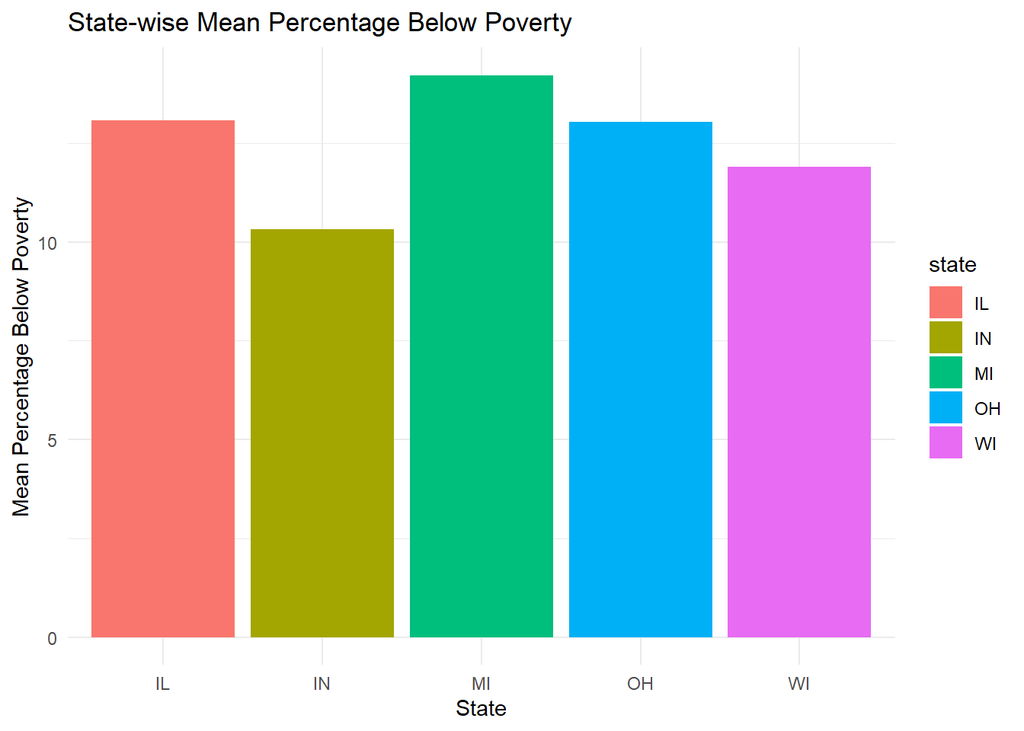

```r
ggplot(statewise_poverty, aes(x = state, y = mean_percbelowpoverty, fill=state)) +
  geom_bar(stat = "identity") +
  labs(title = "State-wise Mean Percentage Below Poverty", x = "State", y = "Mean Percentage Below Poverty") +
  theme_minimal()
```

## Hypothesis 1: Poverty vs Race

“Racial disparity here is extreme, and it has also not always been that way. It is mutable,” said Laura Dresser, associate director of COWS, a University of Wisconsin-Madison research institute, and author of the Wisconsin breakout. “It is a moral and an economic problem, and it requires state investment and state attention to the issues of all people, not just people of color.”

I want to explore more on this concept and see if this dataset can provide proof of above statement.

Null Hypothesis (H0): null hypothesis: The percentage of black population (percblack) has no significant effect on the percentage of people below the poverty line

Alternative Hypothesis (H1):There is a significant relationship between the percblack and the percentage of people below the poverty line (percbelowpoverty)

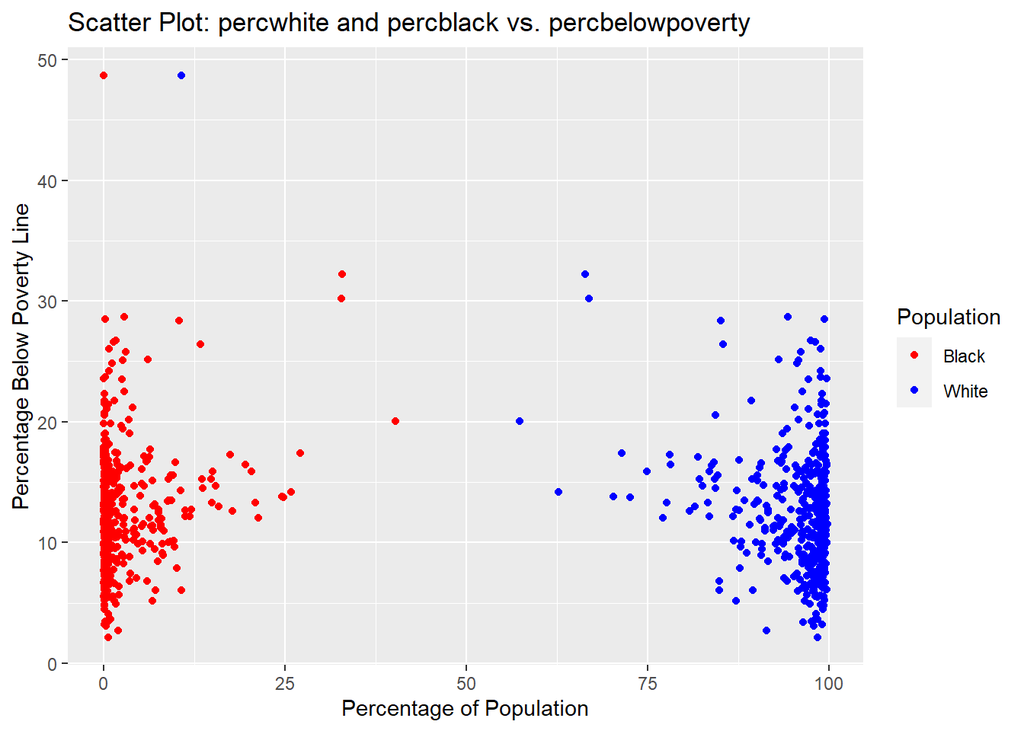

```r
df2<-df %>% count(percwhite, percblack, percbelowpoverty, percchildbelowpovert, county, state) %>% arrange(state, county)

# Scatter plot for both percwhite and percblack against percbelowpoverty
ggplot(df2, aes(x = percwhite, y = percbelowpoverty, color = "White")) +
  geom_point() +
  geom_point(aes(x = percblack, y = percbelowpoverty, color = "Black")) +
  labs(title = "Scatter Plot: percwhite and percblack vs. percbelowpoverty",
       x = "Percentage of Population",
       y = "Percentage Below Poverty Line",
       color = "Population") +
  scale_color_manual(values = c("White" = "blue", "Black" = "red"))
```

```r
cor_matrix<-cor(df2[, c("percwhite", "percblack", "percbelowpoverty")])
cor_matrix
```

```
##                   percwhite  percblack percbelowpoverty
## percwhite         1.0000000 -0.7595847       -0.3765876
## percblack        -0.7595847  1.0000000        0.2179625
## percbelowpoverty -0.3765876  0.2179625        1.0000000
```

- The correlation coefficient between percwhite and percbelowpoverty is approximately -0.377, indicating a moderate negative correlation suggesting that as the percentage of the white population increases, the percentage of people below the poverty line tends to decrease, and vice versa.
- The correlation coefficient between percblack and percbelowpoverty is approximately 0.218, indicating a positive correlation. This suggests that as the percentage of the black population increases, the percentage of people below the poverty line tends to increase, and vice versa.

Correlation does not imply causation, so while these correlations suggest associations between the variables, it doesn’t necessarily mean that one variable causes another.Other factors and confounding variables may influence the relationships, further analysis and statistical can be done to check.

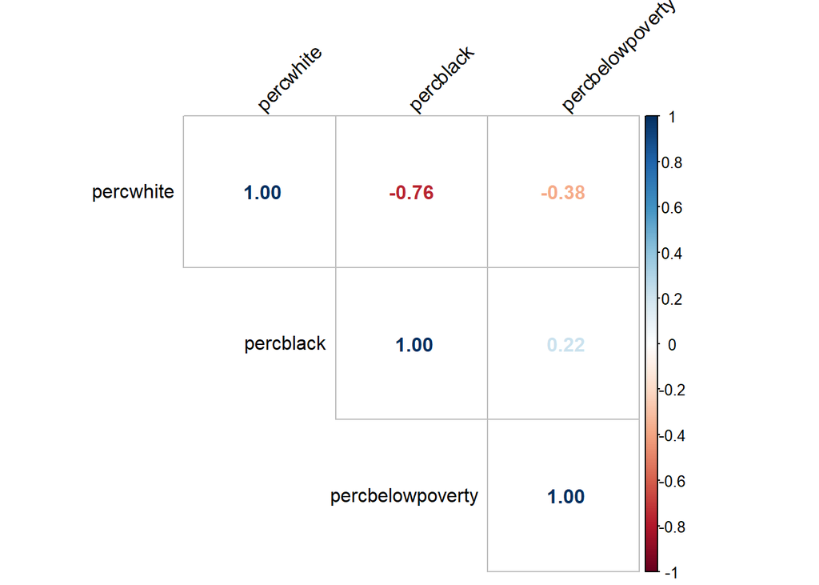

```r
library(corrplot)
corrplot(cor_matrix,
         #method = "color",
         #method = "ellipse",
         method = "number",
         type = "upper",
         tl.col = "black",
         tl.srt = 45)
```

```r
correlation_coefficient <- cor(df$percblack, df$percbelowpoverty)
print(paste("Correlation Coefficient: ", correlation_coefficient))
```

```
## [1] "Correlation Coefficient:  0.217962489667452"
```

The value of 0.218 suggests a relatively weak positive correlation. Correlation coefficients range from -1 to 1, where 1 indicates a perfect positive correlation, 0 indicates no correlation, and -1 indicates a perfect negative correlation.

```r
# Linear regression model
model <- lm(percbelowpoverty ~ percblack, data = df)
summary(model)
```

```
##
## Call:
## lm(formula = percbelowpoverty ~ percblack, data = df)
##
## Residuals:
##    Min     1Q Median     3Q    Max
## -9.893 -3.367 -0.653  2.350 36.766
##
## Coefficients:
##             Estimate Std. Error t value Pr(>|t|)
## (Intercept) 11.92553    0.27151  43.923  < 2e-16 ***
## percblack    0.21857    0.04692   4.658 4.25e-06 ***
## ---
## Signif. codes:  0 '***' 0.001 '**' 0.01 '*' 0.05 '.' 0.1 ' ' 1
##
## Residual standard error: 5.032 on 435 degrees of freedom
## Multiple R-squared:  0.04751,    Adjusted R-squared:  0.04532
## F-statistic:  21.7 on 1 and 435 DF,  p-value: 4.25e-06
```

- The coefficient for percblack is 0.21857. This indicates that for every one-unit increase in the percentage of black population, the estimated percentage below the poverty line increases by 0.21857.
- The p-value associated with percblack is very low (4.25e-06), there is strong evidence to reject the null hypothesis that the coefficient is zero. The statistically significant p-value for percblack indicates that the relationship is not likely due to random chance.
- The R-squared values suggest that the model explains only a small portion of the variability in percbelowpoverty, and other factors may contribute to the observed patterns.This suggests that a significant portion of the variation in poverty rates is not captured by the percentage of black population alone.

## Hypothesis 2 : Education vs Race

Goal here is to investigate whether there is a statistically significant relationship between the percentage of Black population in a given state and the educational attainment of its population. Do the percentages of high school graduates vary significantly across different racial groups in the Midwest?

Null Hypothesis (H0): The racial composition (specifically, the percentage of Black population - percblack) has no significant effect on the education level of the population (measured by the percentage with a college degree - percollege).

Alternative Hypothesis (H1): The racial composition (percblack) has a significant effect on the education level of the population (percollege).

```r
lm_blk <- lm(percollege ~ percblack, data = df)
summary(lm_blk)
```

```
##
## Call:
## lm(formula = percollege ~ percblack, data = df)
##
## Residuals:
##     Min      1Q  Median      3Q     Max
## -15.773  -3.862  -1.416   2.257  27.337
##
## Coefficients:
##             Estimate Std. Error t value Pr(>|t|)
## (Intercept) 17.49846    0.32859  53.253  < 2e-16 ***
## percblack    0.28931    0.05679   5.094 5.23e-07 ***
## ---
## Signif. codes:  0 '***' 0.001 '**' 0.01 '*' 0.05 '.' 0.1 ' ' 1
##
## Residual standard error: 6.09 on 435 degrees of freedom
## Multiple R-squared:  0.0563, Adjusted R-squared:  0.05413
## F-statistic: 25.95 on 1 and 435 DF,  p-value: 5.227e-07
```

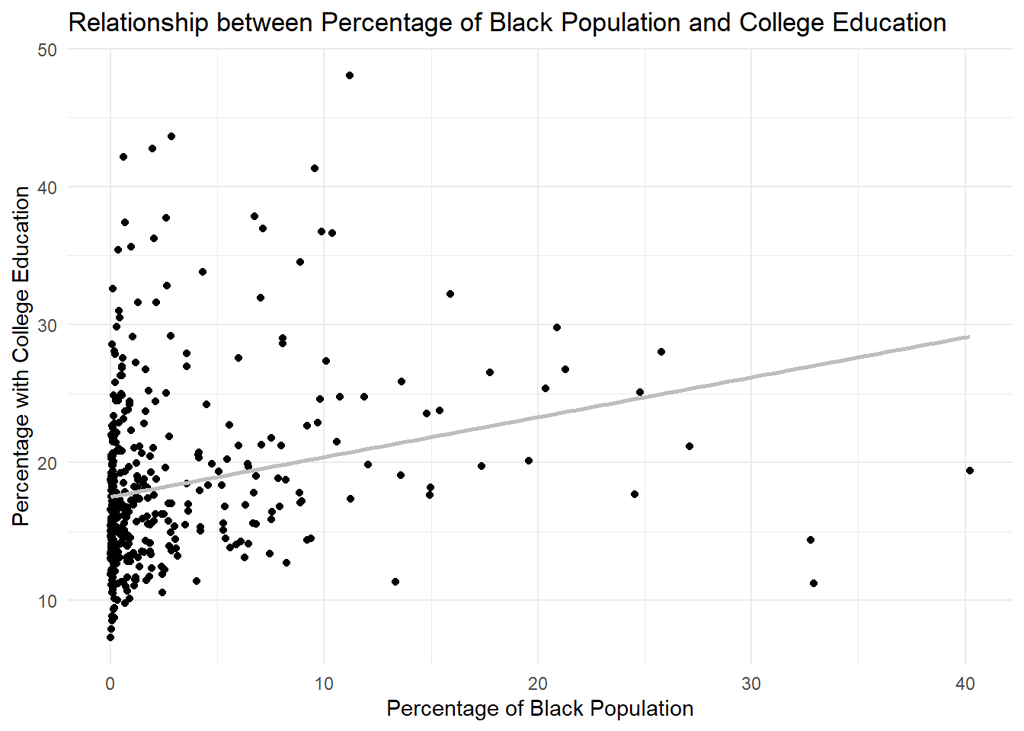

```r
# Visualize percblack vs percollege
ggplot(midwest, aes(x = percblack, y = percollege)) +
  geom_point() +
  geom_smooth(method = "lm", se = FALSE, color = "grey") +
  labs(title = "Relationship between Percentage of Black Population and College Education",
       x = "Percentage of Black Population",
       y = "Percentage with College Education") +
  theme_minimal()
```

The model here shows significant positive relationship between the percentage of Black population and the percentage of college graduates. However, the overall explanatory power of the model is relatively low, as indicated by the low R-squared values.

```r
lm_wht <- lm(percollege ~ percwhite, data = df)
summary(lm_wht)
```

```
##
## Call:
## lm(formula = percollege ~ percwhite, data = df)
##
## Residuals:
##     Min      1Q  Median      3Q     Max
## -27.038  -3.929  -1.547   2.431  27.527
##
## Coefficients:
##             Estimate Std. Error t value Pr(>|t|)
## (Intercept) 36.40291    3.96446   9.182  < 2e-16 ***
## percwhite   -0.18973    0.04137  -4.586 5.92e-06 ***
## ---
## Signif. codes:  0 '***' 0.001 '**' 0.01 '*' 0.05 '.' 0.1 ' ' 1
##
## Residual standard error: 6.123 on 435 degrees of freedom
## Multiple R-squared:  0.04611,    Adjusted R-squared:  0.04392
## F-statistic: 21.03 on 1 and 435 DF,  p-value: 5.923e-06
```

The results suggest that the percentage of White population (percwhite) has some effect on the percentage with a college degree. However, the R-squared value is relatively low.

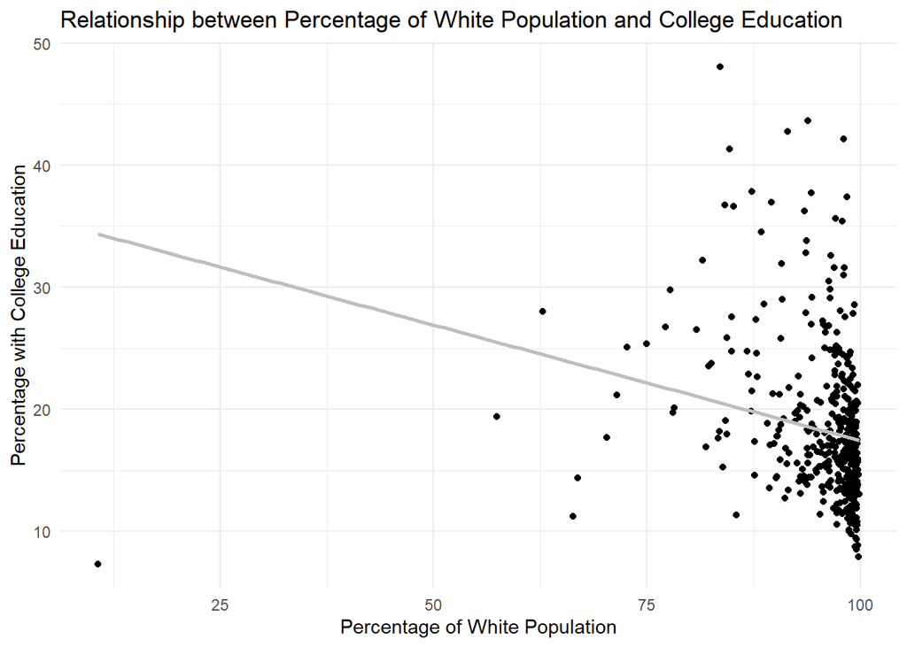

```r
ggplot(midwest, aes(x = percwhite, y = percollege)) +
  geom_point() +
  geom_smooth(method = "lm", se = FALSE, color = "grey") +
  labs(title = "Relationship between Percentage of White Population and College Education",
       x = "Percentage of White Population",
       y = "Percentage with College Education") +
  theme_minimal()
```

```r
lm_result <- lm(percollege ~ percwhite + percblack, data = df)
summary(lm_result)
```

```
##
## Call:
## lm(formula = percollege ~ percwhite + percblack, data = df)
##
## Residuals:
##     Min      1Q  Median      3Q     Max
## -16.481  -3.827  -1.421   2.302  27.116
##
## Coefficients:
##             Estimate Std. Error t value Pr(>|t|)
## (Intercept) 24.58760    6.23016   3.947 9.25e-05 ***
## percwhite   -0.07207    0.06325  -1.139   0.2551
## percblack    0.21376    0.08728   2.449   0.0147 *
## ---
## Signif. codes:  0 '***' 0.001 '**' 0.01 '*' 0.05 '.' 0.1 ' ' 1
##
## Residual standard error: 6.088 on 434 degrees of freedom
## Multiple R-squared:  0.05912,    Adjusted R-squared:  0.05478
## F-statistic: 13.63 on 2 and 434 DF,  p-value: 1.809e-06
```

The results suggest that, when considering both percwhite and percblack together, the percentage of Black population (percblack) has a significant effect on the percentage with a college degree, while the percentage of White population (percwhite) does not show a significant effect. However, the R-squared value is still relatively low.

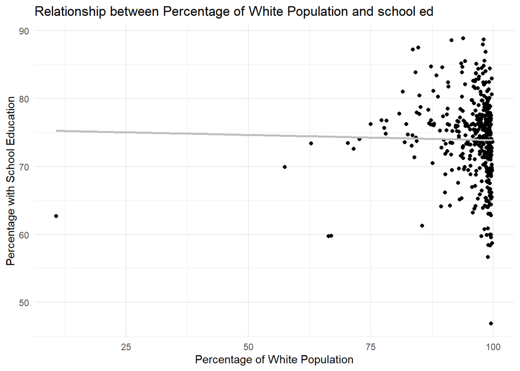

```r
ggplot(midwest, aes(x = percwhite, y = perchsd)) +
  geom_point() +
  geom_smooth(method = "lm", se = FALSE, color = "grey") +
  labs(title = "Relationship between Percentage of White Population and school ed",
       x = "Percentage of White Population",
       y = "Percentage with School Education") +
  theme_minimal()
```

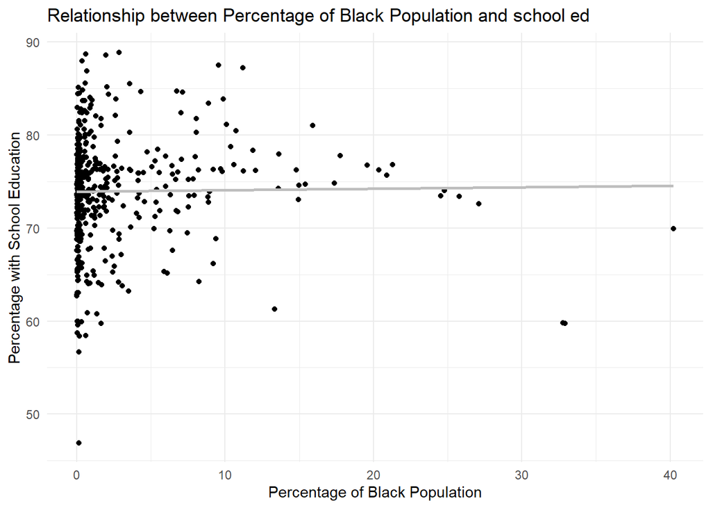

```r
ggplot(midwest, aes(x = percblack, y = perchsd)) +
  geom_point() +
  geom_smooth(method = "lm", se = FALSE, color = "grey") +
  labs(title = "Relationship between Percentage of Black Population and school ed",
       x = "Percentage of Black Population",
       y = "Percentage with School Education") +
  theme_minimal()
```

# Conclusion:

## Conclusion 1: Race vs Poverty

- States with a higher percentage of Black population tend to have higher poverty rates. Wisconsin (WI) stands out with the highest mean percentage of the “other” racial group but comparatively lower poverty rate
- Linear modeling shows significant positive relationship between the percentage of Black population (percblack) and the percentage of people below the poverty line (percbelowpoverty). On average, a one-unit increase in percblack is associated with a 0.21857 increase in percbelowpoverty.But explanatory power of the model is low, with an R-squared of 0.04751.

# To note:

Other Influencing Factors: Poverty rates are influenced by a myriad of factors, including economic conditions, education, employment opportunities, government policies, and more. The model does not include these additional factors, and their omission can limit the model’s ability to fully explain the observed patterns.

Correlation vs. Causation: While there is a statistically significant positive correlation between the percentage of black population and poverty rates, correlation does not imply causation. The model does not establish a causal relationship between percblack and percbelowpoverty.

Omitted Variable Bias: The model may suffer from omitted variable bias, where important variables that influence poverty rates are not included. The exclusion of relevant variables can lead to inaccurate and biased estimates of the coefficients.

# Application:

Investigating the distribution of resources and opportunities among racial groups is crucial for promoting social equity and justice. Understanding disparities in income, education, and poverty levels can help identify areas that may require targeted interventions.

Findings from this exploration can inform the development of targeted policies and programs aimed at reducing disparities and promoting inclusivity. Policymakers can use the insights gained to make interventions and develop policies, programs targeting specific groups/communitites.

Communities can benefit from a better understanding of the socioeconomic landscape. Identifying strengths and challenges within different racial groups allows for more informed community engagement and empowerment initiatives.

This exploration contributes to the broader understanding of regional disparities and adds valuable insights to the existing body of literature on socio-economic factors in the Midwest.